# EDA Project

Leo

2019年1月15日

# White Wine Exploration

This report explores a dataset containing quality and attributes for approximately 4,898 white wine.

# Univariate Plots Section

```
## [1] 4898   13
```

```
## 'data.frame':    4898 obs. of  13 variables:
##  $ X                   : int  1 2 3 4 5 6 7 8 9 10 ...
##  $ fixed.acidity       : num  7 6.3 8.1 7.2 7.2 8.1 6.2 7 6.3 8.1 ...
##  $ volatile.acidity    : num  0.27 0.3 0.28 0.23 0.23 0.28 0.32 0.27 0.3 0.22 ...
##  $ citric.acid         : num  0.36 0.34 0.4 0.32 0.32 0.4 0.16 0.36 0.34 0.43 ...
##  $ residual.sugar      : num  20.7 1.6 6.9 8.5 8.5 6.9 7 20.7 1.6 1.5 ...
##  $ chlorides           : num  0.045 0.049 0.05 0.058 0.058 0.05 0.045 0.045 0.049 0.044 ...
##  $ free.sulfur.dioxide : num  45 14 30 47 47 30 30 45 14 28 ...
##  $ total.sulfur.dioxide: num  170 132 97 186 186 97 136 170 132 129 ...
##  $ density             : num  1.001 0.994 0.995 0.996 0.996 ...
##  $ pH                  : num  3 3.3 3.26 3.19 3.19 3.26 3.18 3 3.3 3.22 ...
##  $ sulphates           : num  0.45 0.49 0.44 0.4 0.4 0.44 0.47 0.45 0.49 0.45 ...
##  $ alcohol             : num  8.8 9.5 10.1 9.9 9.9 10.1 9.6 8.8 9.5 11 ...
##  $ quality             : int  6 6 6 6 6 6 6 6 6 6 ...
```

```
##        X        fixed.acidity    volatile.acidity  citric.acid
##  Min.   :   1   Min.   : 3.800   Min.   :0.0800   Min.   :0.0000
##  1st Qu.:1225   1st Qu.: 6.300   1st Qu.:0.2100   1st Qu.:0.2700
##  Median :2450   Median : 6.800   Median :0.2600   Median :0.3200
##  Mean   :2450   Mean   : 6.855   Mean   :0.2782   Mean   :0.3342
##  3rd Qu.:3674   3rd Qu.: 7.300   3rd Qu.:0.3200   3rd Qu.:0.3900
##  Max.   :4898   Max.   :14.200   Max.   :1.1000   Max.   :1.6600
##  residual.sugar     chlorides       free.sulfur.dioxide
##  Min.   : 0.600   Min.   :0.00900   Min.   :  2.00
##  1st Qu.: 1.700   1st Qu.:0.03600   1st Qu.: 23.00
##  Median : 5.200   Median :0.04300   Median : 34.00
##  Mean   : 6.391   Mean   :0.04577   Mean   : 35.31
##  3rd Qu.: 9.900   3rd Qu.:0.05000   3rd Qu.: 46.00
##  Max.   :65.800   Max.   :0.34600   Max.   :289.00
##  total.sulfur.dioxide    density             pH          sulphates
##  Min.   :  9.0        Min.   :0.9871   Min.   :2.720   Min.   :0.2200
##  1st Qu.:108.0        1st Qu.:0.9917   1st Qu.:3.090   1st Qu.:0.4100
##  Median :134.0        Median :0.9937   Median :3.180   Median :0.4700
##  Mean   :138.4        Mean   :0.9940   Mean   :3.188   Mean   :0.4898
##  3rd Qu.:167.0        3rd Qu.:0.9961   3rd Qu.:3.280   3rd Qu.:0.5500
##  Max.   :440.0        Max.   :1.0390   Max.   :3.820   Max.   :1.0800
##     alcohol         quality
##  Min.   : 8.00   Min.   :3.000
##  1st Qu.: 9.50   1st Qu.:5.000
##  Median :10.40   Median :6.000
##  Mean   :10.51   Mean   :5.878
##  3rd Qu.:11.40   3rd Qu.:6.000
##  Max.   :14.20   Max.   :9.000
```

this dataset consist of 13 variables and 4,898 observaions. Here we consider quality as a factor rather than a numeric variable.

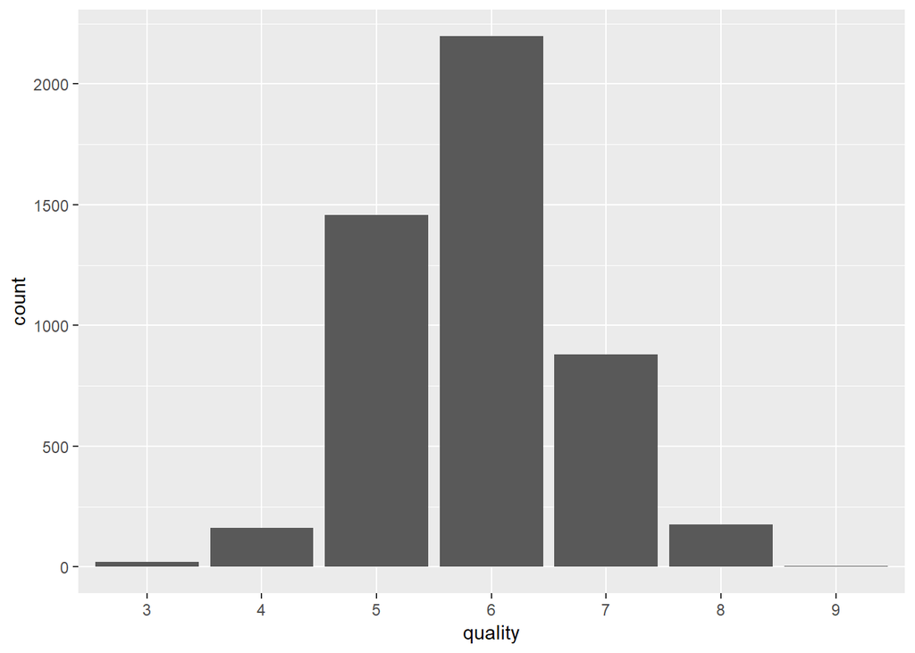

As we can see in the plot, the quality data distribution appears normal and peak around 6, and wine with higher quality(which have quality above 6) is less than those with lower quality(which have quality under 6). Now, I wonder whether other variables will have similar distribution. Among them, `free sulfur dioxide`, `total sulfur dioxide`, `sulphates` seems have relation, `density` may influenced by `residual sugar` and `alcohol`, we may explore them latter.

```
##   0%  25%  50%  75% 100%
##  3.8  6.3  6.8  7.3 14.2
```

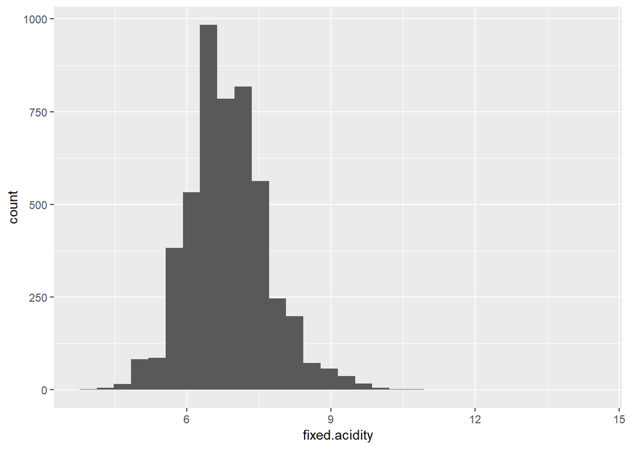

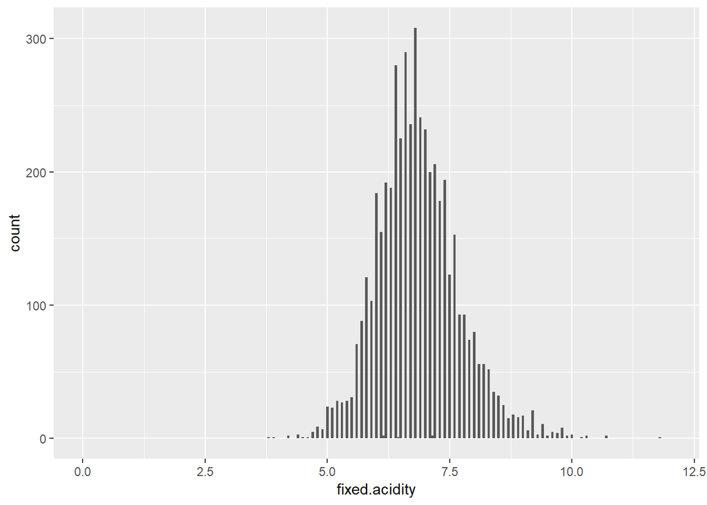

Most wine have fixed.acidity between [6.3, 7.3]

```
##   0%  25%  50%  75% 100%
## 0.08 0.21 0.26 0.32 1.10
```

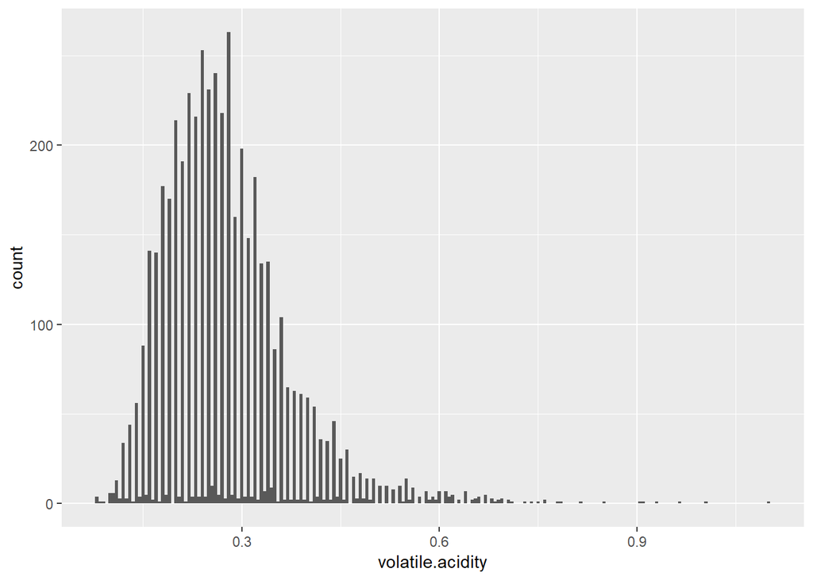

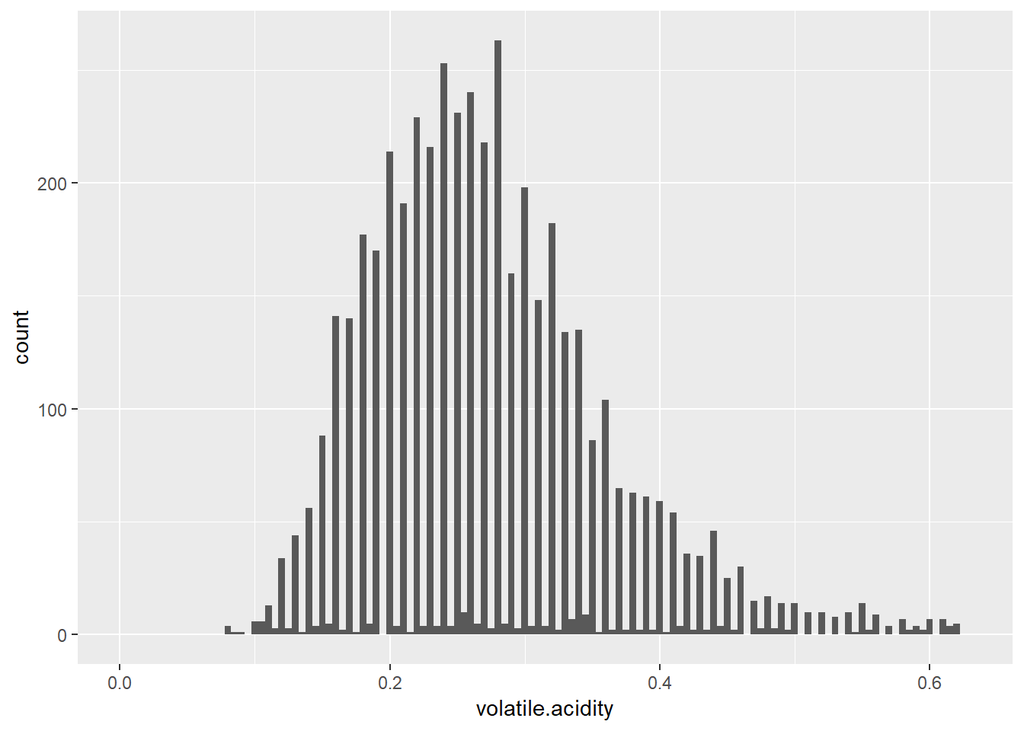

Most wine have volatile.acidity between [0.21, 0.32]

```
##   0%  25%  50%  75% 100%
## 0.00 0.27 0.32 0.39 1.66
```

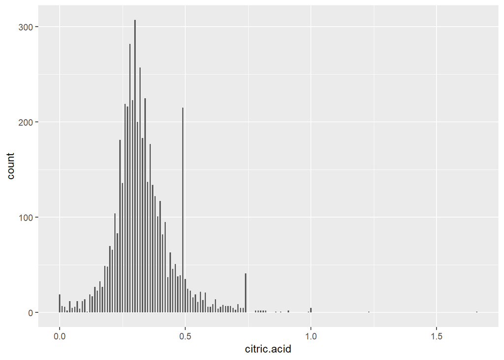

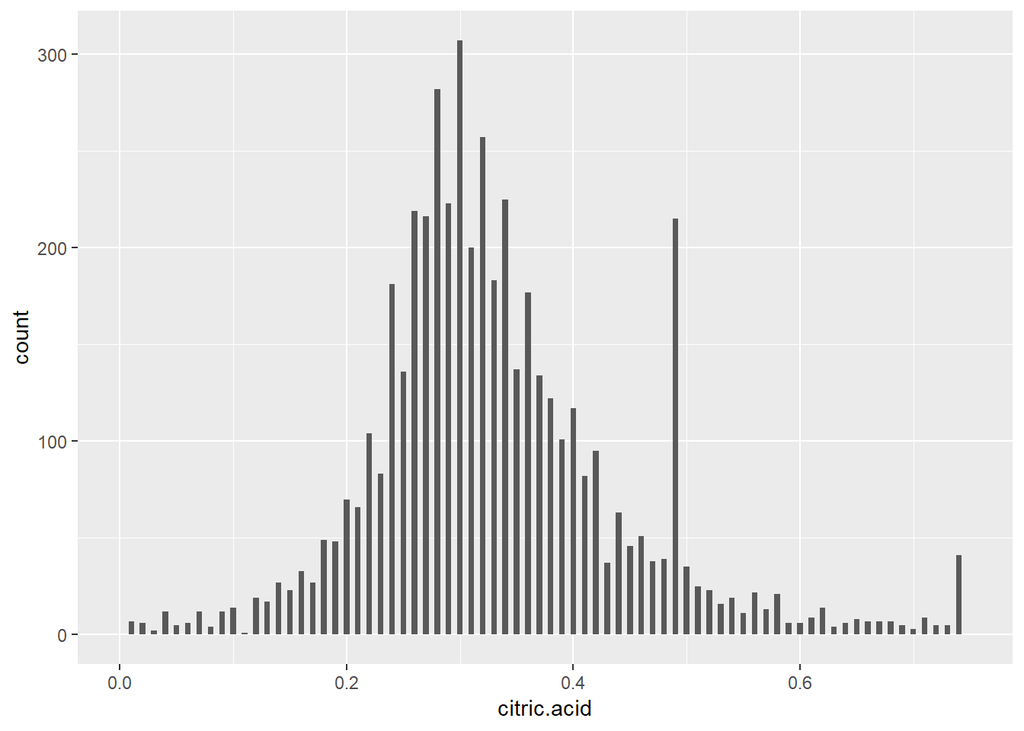

```
##   0%  25%  50%  75% 100%
##  0.6  1.7  5.2  9.9 65.8
```

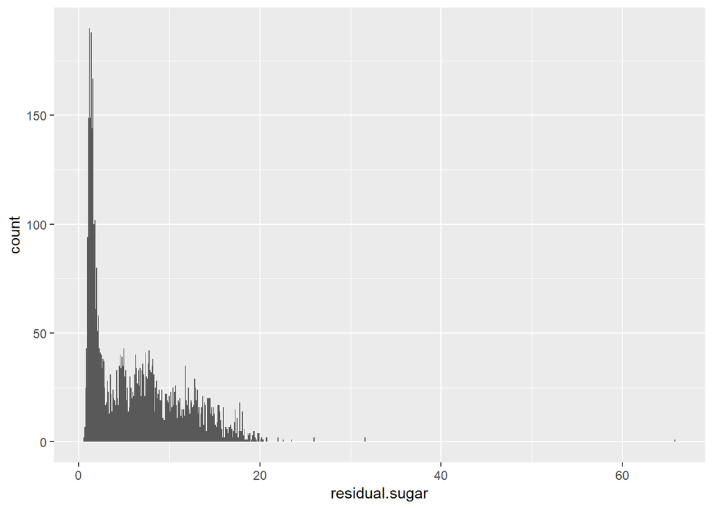

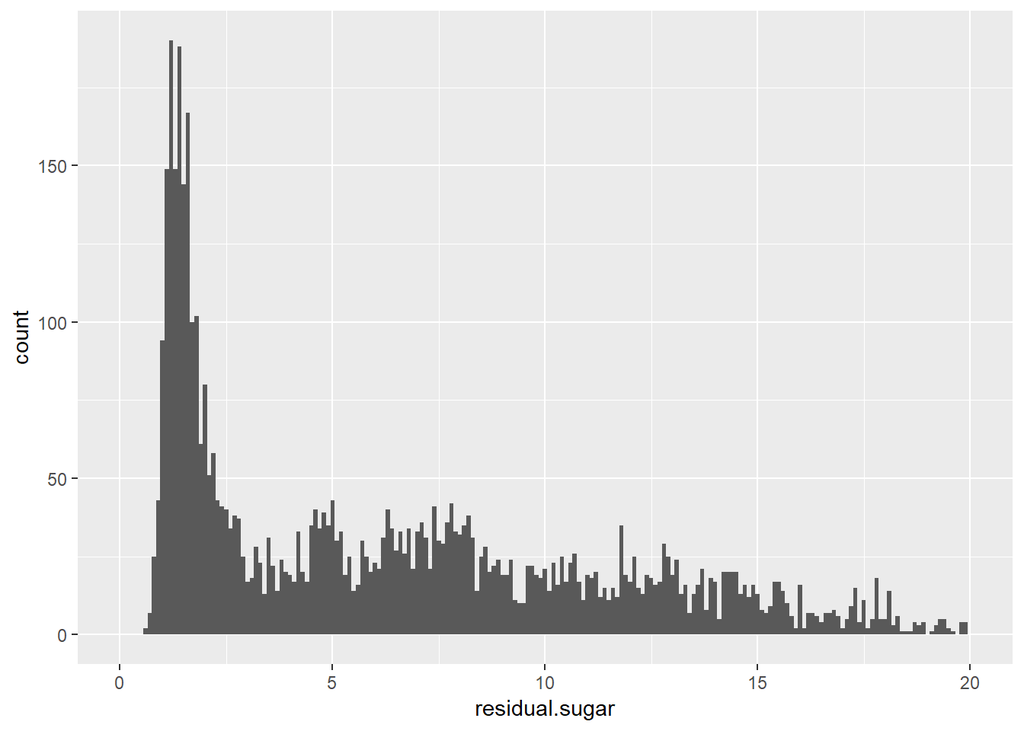

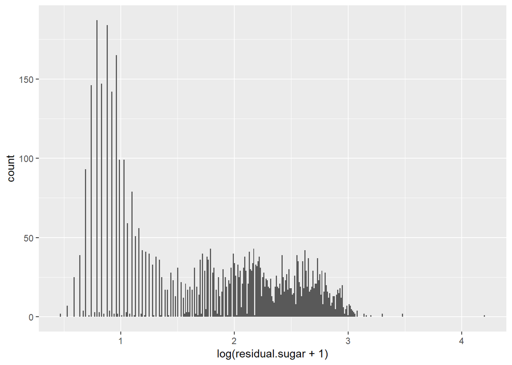

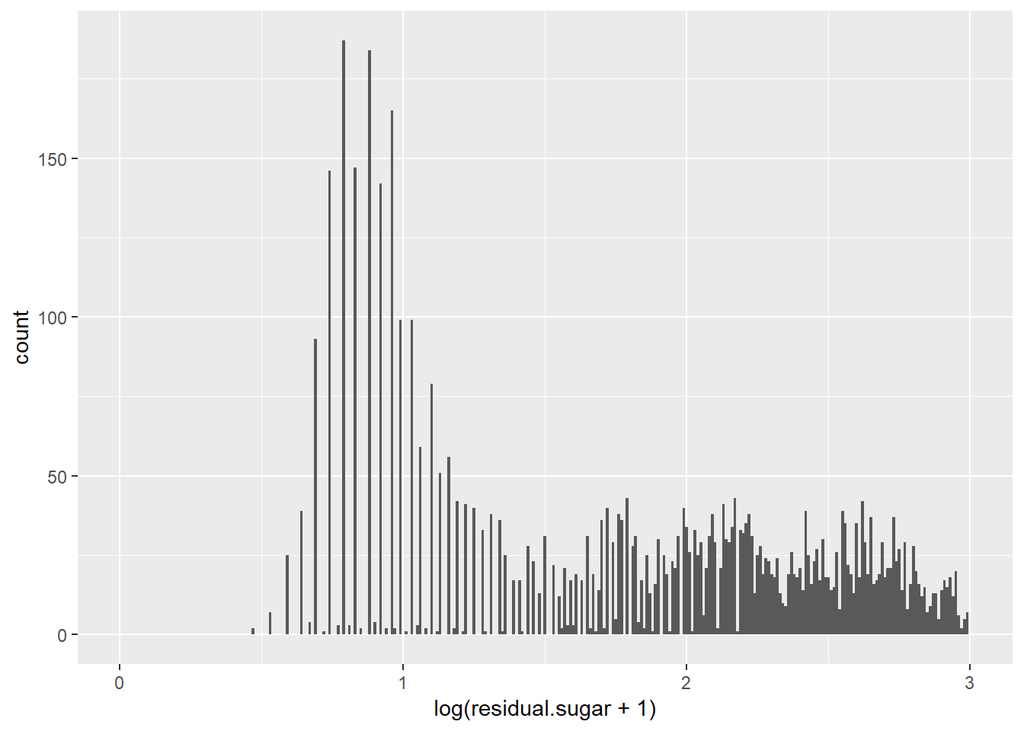

Most wine have residual.sugar between [1.7, 9.9], also, a bunch of them is above 9.9.

```
##    0%   25%   50%   75%  100%
## 0.009 0.036 0.043 0.050 0.346
```

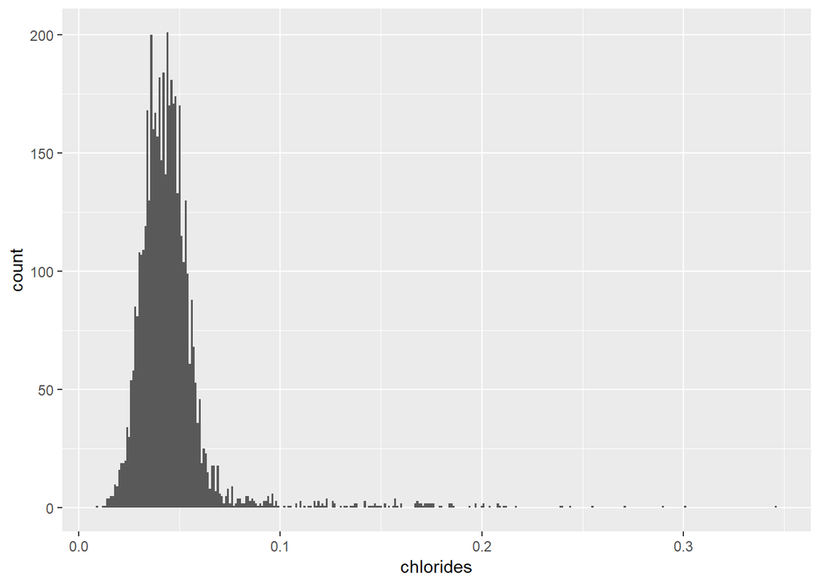

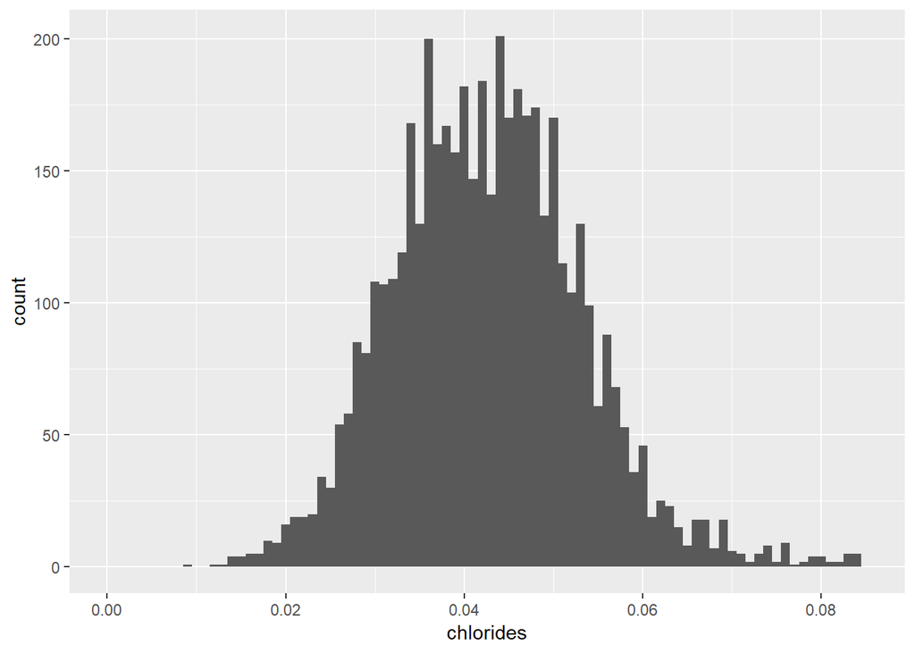

Most wine have chlorides between [0.036, 0.050].

```
##   0%  25%  50%  75% 100%
##    2   23   34   46  289
```

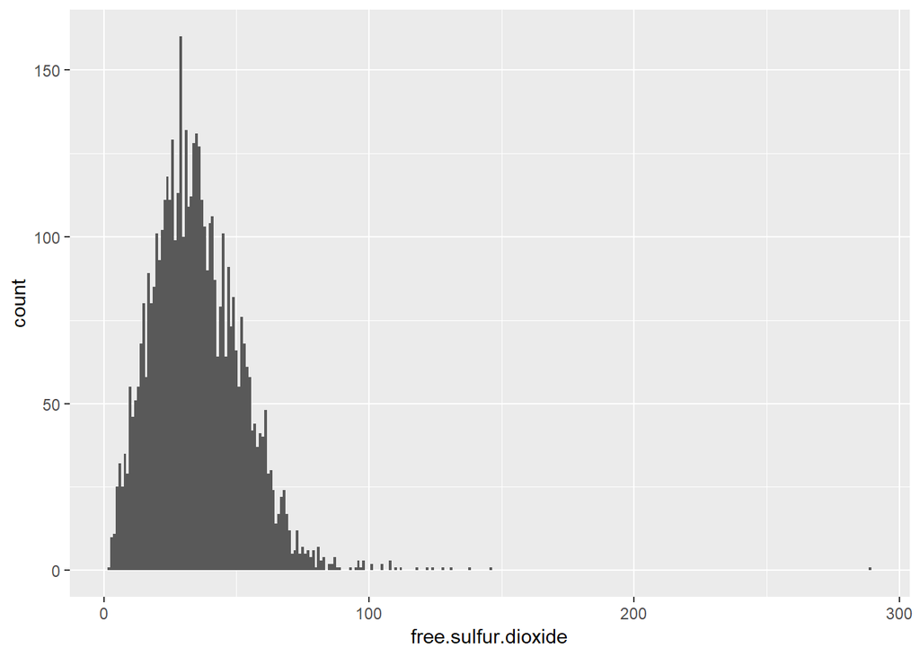

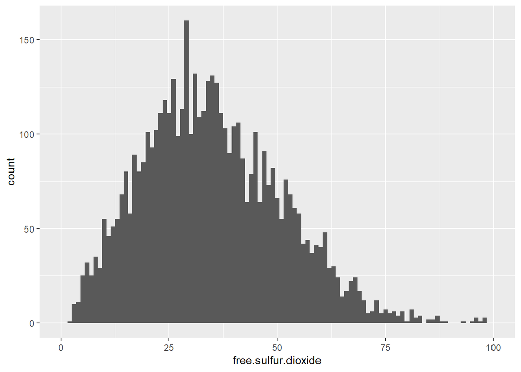

Most wine have free.sulfur.dioxide between [23, 46]

```
##   0%  25%  50%  75% 100%
##    9  108  134  167  440
```

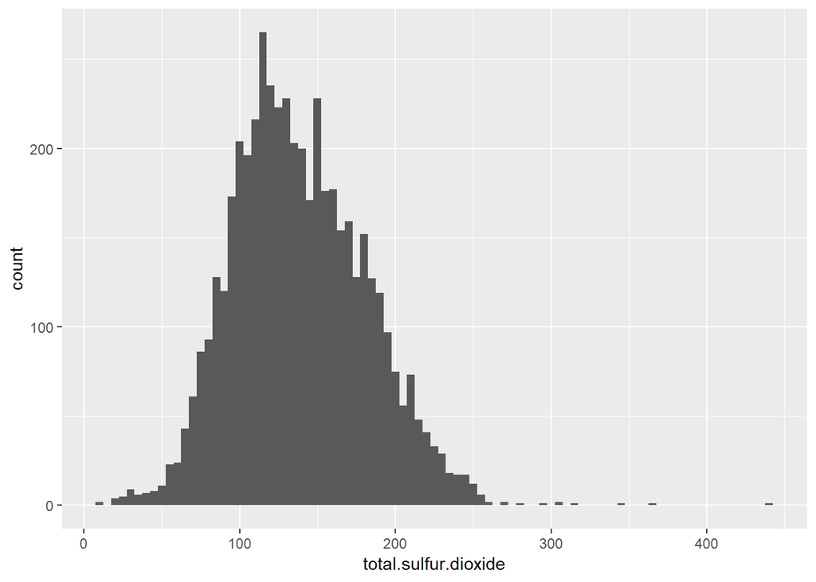

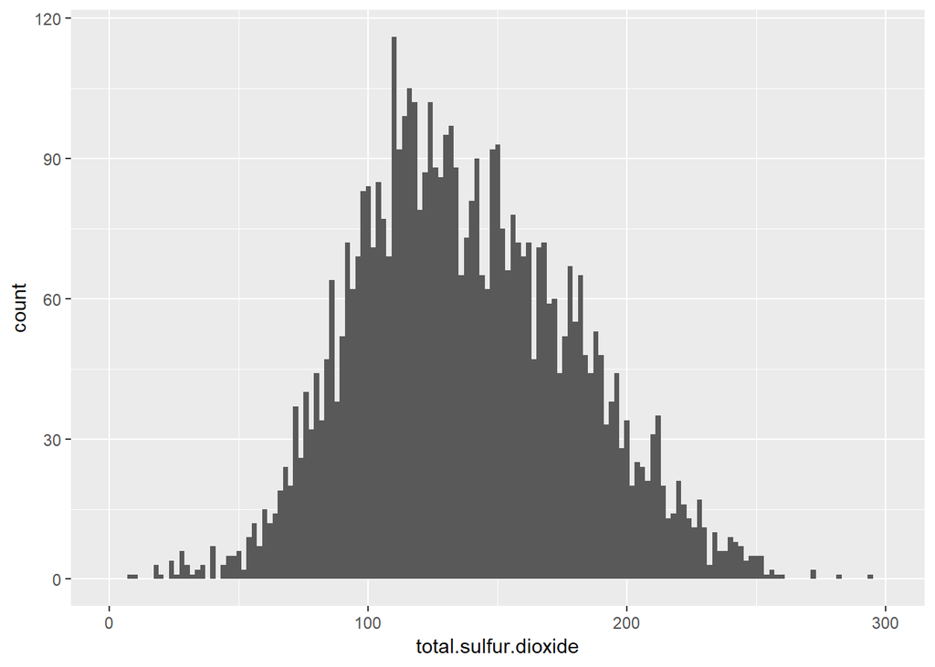

Most wine have total.sulfur.dioxide between [108, 167]

```
##        0%       25%       50%       75%      100%
## 0.9871100 0.9917225 0.9937400 0.9961000 1.0389800
```

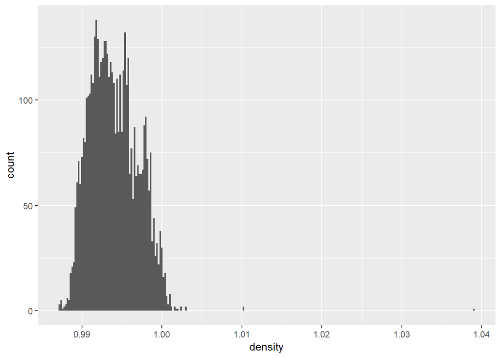

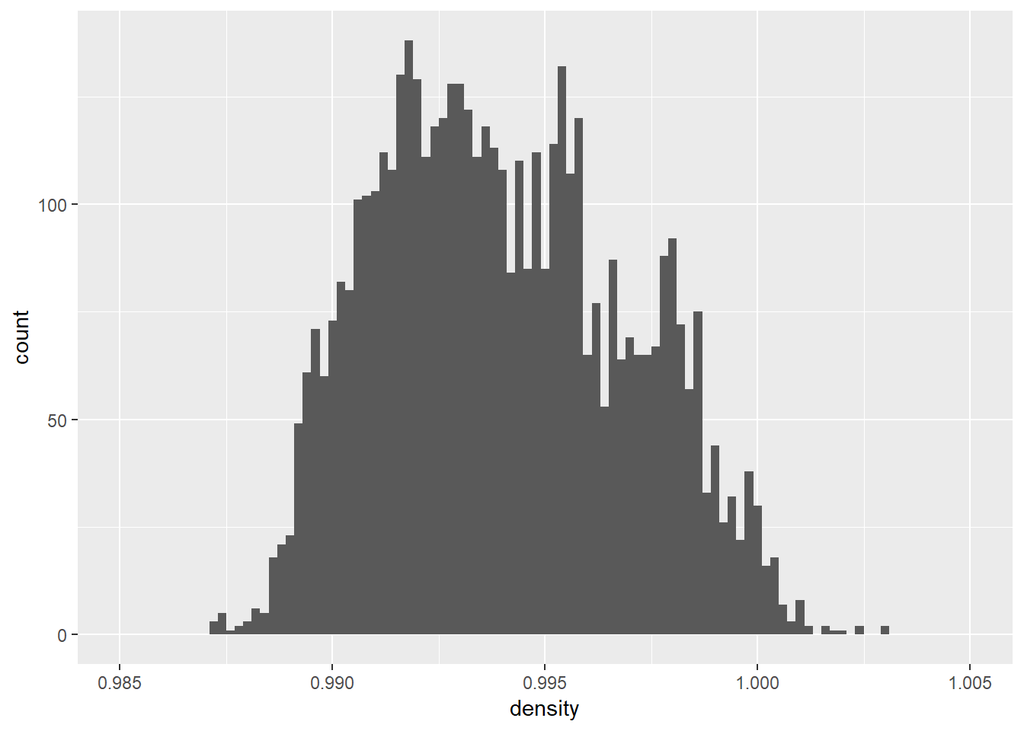

Most wine have density between [0.992, 0.996]

```
##   0%  25%  50%  75% 100%
## 2.72 3.09 3.18 3.28 3.82
```

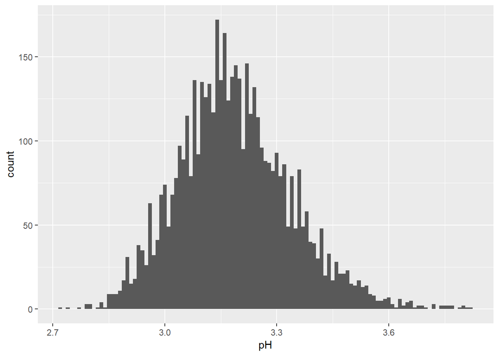

Most wine have pH between [3.09, 3.28]

```
##   0%  25%  50%  75% 100%
## 0.22 0.41 0.47 0.55 1.08
```

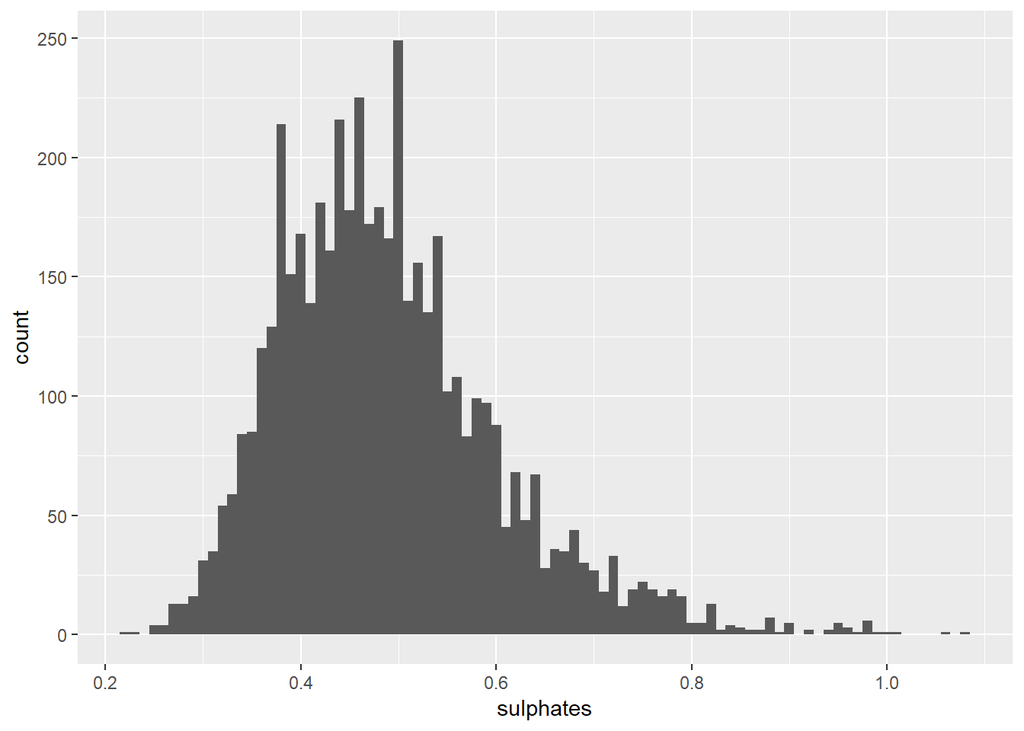

Most wine have sulphates between [0.41, 0.55]

```
##   0%  25%  50%  75% 100%
##  8.0  9.5 10.4 11.4 14.2
```

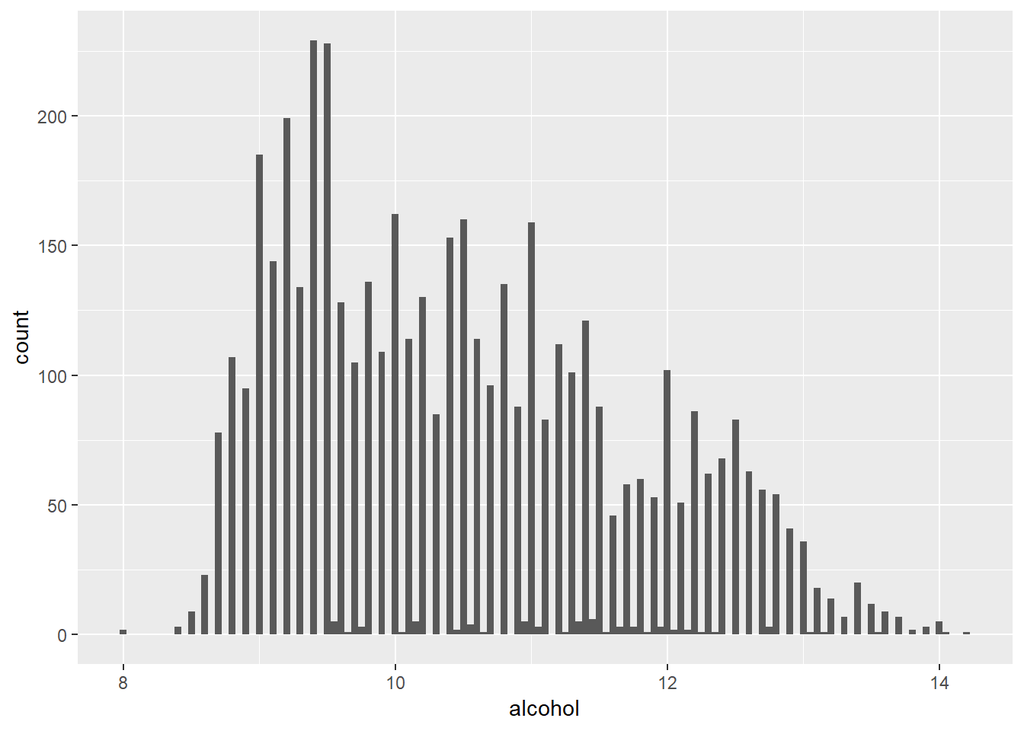

From histograms above, we notice that most variables have normal distribution or a distribution like it.

# Univariate Analysis

### What is the structure of your dataset?

There are 4,898 bottles of wine in the dataset with 12 variables, the variable quality is ordered by 0-10(0 is worst).

### What is/are the main feature(s) of interest in your dataset?

Main features in the dataset are quality, sulphates, citric.acid. I’d like to determine which features are best for predicting the quality of a bottle of white wine. According the txt file, I suspect citric.acid. and some combination of the other variables can be used to build a predictive model to judge the quality of white wine.

### What other features in the dataset do you think will help support your investigation into your feature(s) of interest?

sulphates, chlorides, residual.sugar, citric.acid may contribute to the quality of wine.

### Did you create any new variables from existing variables in the dataset?

No, I don’t think new variable will help us with quality of wine. I delete X variable.

### Of the features you investigated, were there any unusual distributions? Did you perform any operations on the data to tidy, adjust, or change the form of the data? If so, why did you do this?

Some variables may have outliers.

Residual.sugar have a different distribution from other variables, it looks like a long tail distribution and I tried log function, but it doesn’t help much.

# Bivariate Plots Section

```
##                      fixed.acidity volatile.acidity citric.acid
## fixed.acidity           1.00000000      -0.02269729  0.28918070
## volatile.acidity       -0.02269729       1.00000000 -0.14947181
## citric.acid             0.28918070      -0.14947181  1.00000000
## residual.sugar          0.08902070       0.06428606  0.09421162
## chlorides               0.02308564       0.07051157  0.11436445
## free.sulfur.dioxide    -0.04939586      -0.09701194  0.09407722
## total.sulfur.dioxide    0.09106976       0.08926050  0.12113080
## density                 0.26533101       0.02711385  0.14950257
## pH                     -0.42585829      -0.03191537 -0.16374821
## sulphates              -0.01714299      -0.03572815  0.06233094
## alcohol                -0.12088112       0.06771794 -0.07572873
##                      residual.sugar   chlorides free.sulfur.dioxide
## fixed.acidity            0.08902070  0.02308564       -0.0493958591
## volatile.acidity         0.06428606  0.07051157       -0.0970119393
## citric.acid              0.09421162  0.11436445        0.0940772210
## residual.sugar           1.00000000  0.08868454        0.2990983537
## chlorides                0.08868454  1.00000000        0.1013923521
## free.sulfur.dioxide      0.29909835  0.10139235        1.0000000000
## total.sulfur.dioxide     0.40143931  0.19891030        0.6155009650
## density                  0.83896645  0.25721132        0.2942104109
## pH                      -0.19413345 -0.09043946       -0.0006177961
## sulphates               -0.02666437  0.01676288        0.0592172458
## alcohol                 -0.45063122 -0.36018871       -0.2501039415
##                      total.sulfur.dioxide     density            pH
## fixed.acidity                 0.091069756  0.26533101 -0.4258582910
## volatile.acidity              0.089260504  0.02711385 -0.0319153683
## citric.acid                   0.121130798  0.14950257 -0.1637482114
## residual.sugar                0.401439311  0.83896645 -0.1941334540
## chlorides                     0.198910300  0.25721132 -0.0904394560
## free.sulfur.dioxide           0.615500965  0.29421041 -0.0006177961
## total.sulfur.dioxide          1.000000000  0.52988132  0.0023209718
## density                       0.529881324  1.00000000 -0.0935914935
## pH                            0.002320972 -0.09359149  1.0000000000
## sulphates                     0.134562367  0.07449315  0.1559514973
## alcohol                      -0.448892102 -0.78013762  0.1214320987
##                        sulphates     alcohol
## fixed.acidity        -0.01714299 -0.12088112
## volatile.acidity     -0.03572815  0.06771794
## citric.acid           0.06233094 -0.07572873
## residual.sugar       -0.02666437 -0.45063122
## chlorides             0.01676288 -0.36018871
## free.sulfur.dioxide   0.05921725 -0.25010394
## total.sulfur.dioxide  0.13456237 -0.44889210
## density               0.07449315 -0.78013762
## pH                    0.15595150  0.12143210
## sulphates             1.00000000 -0.01743277
## alcohol              -0.01743277  1.00000000
```

As we mentioned before, `free sulfur dioxide` is a part of `total sulfur dioxide`, however `sulphates` seems have no relation with them. As we expected, `density` influenced by `residual sugar` and `alcohol`, it also have moderate relation with `total sulfur dioxide`.

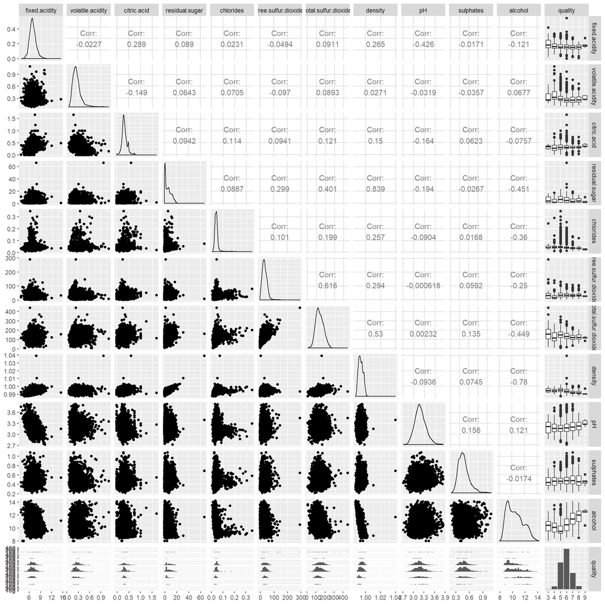

Here, from boxplots, we could see `quality` has a weak relation with `alchol` and `density`. `fixed acidity`, `volatile acidity`, `chlorides` and `total sulfur dioxide` may also influence it.

First, let’s see `free sulfur dioxide` and `total sulfur dioxide`.

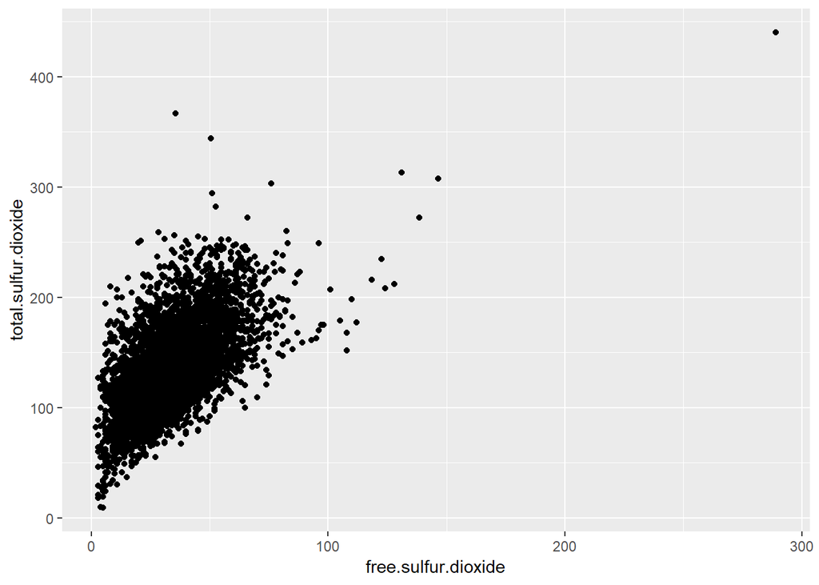

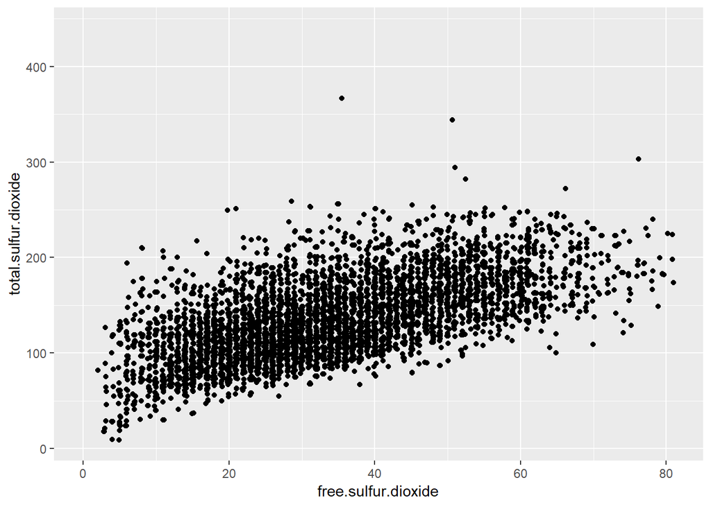

There seems a linear relation between two variables according plot above, so we could try lm function.

```
##
## Call:
## lm(formula = total.sulfur.dioxide ~ free.sulfur.dioxide, data = wineQuality)
##
## Residuals:
##     Min      1Q  Median      3Q     Max
## -98.163 -24.891  -3.273  21.407 227.844
##
## Coefficients:
##                     Estimate Std. Error t value Pr(>|t|)
## (Intercept)         84.05553    1.10304   76.20   <2e-16 ***
## free.sulfur.dioxide  1.53804    0.02815   54.65   <2e-16 ***
## ---
## Signif. codes:  0 '***' 0.001 '**' 0.01 '*' 0.05 '.' 0.1 ' ' 1
##
## Residual standard error: 33.5 on 4896 degrees of freedom
## Multiple R-squared:  0.3788, Adjusted R-squared:  0.3787
## F-statistic:  2986 on 1 and 4896 DF,  p-value: < 2.2e-16
```

As we expected, there’s a linear relation between these two variables. Next we’ll take a look at density and related variables, explore their relationship, see if we could substitude it when we explore the quality.

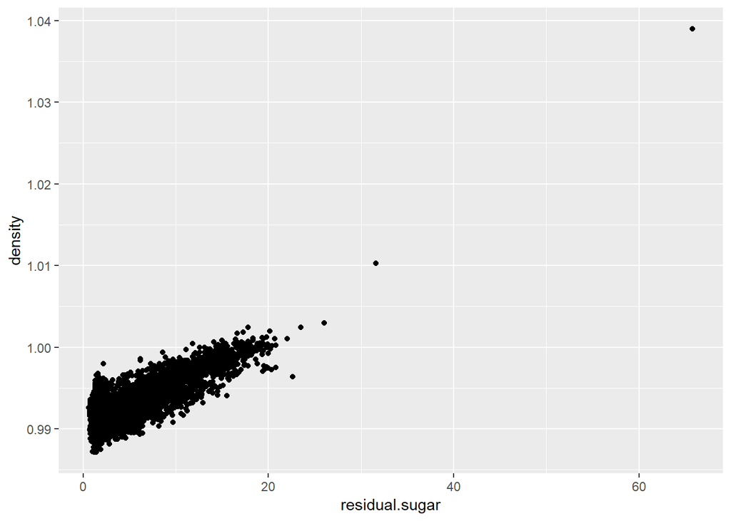

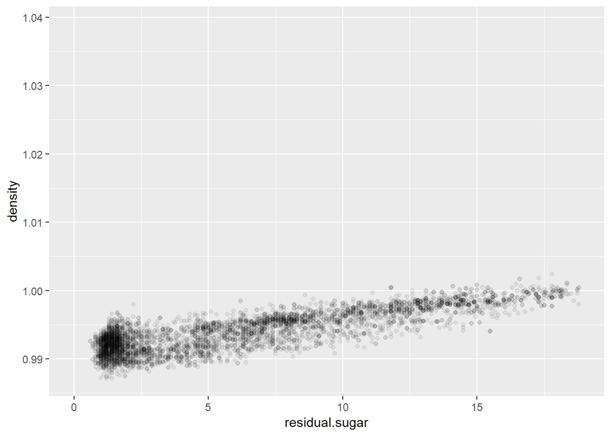

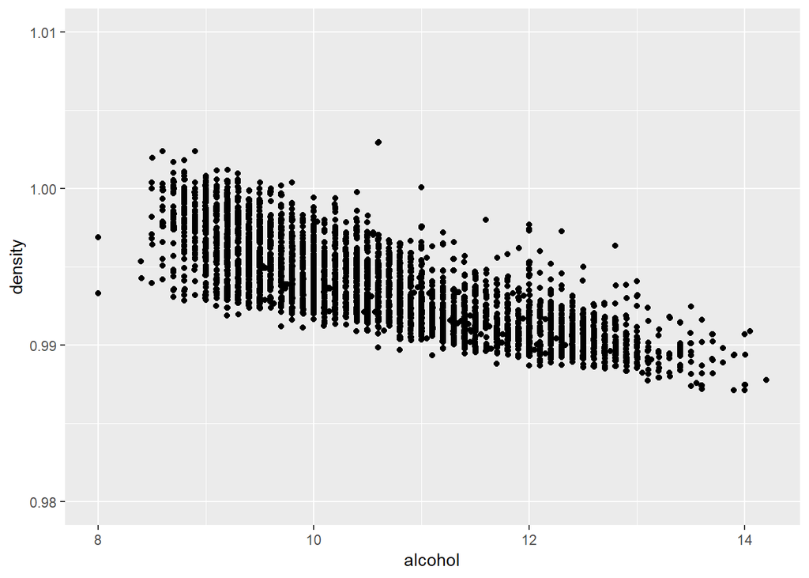

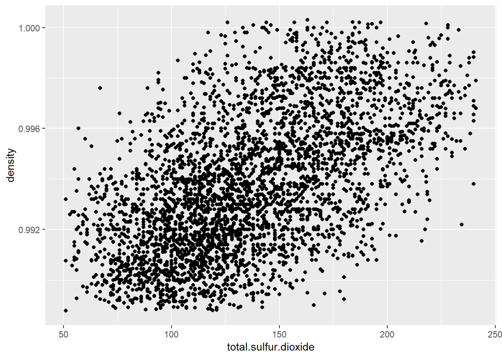

```
##
## Calls:
## d_r.s_model: lm(formula = density ~ residual.sugar, data = wineQuality)
## d_al_model: lm(formula = density ~ alcohol, data = wineQuality)
## d_r.sal_model: lm(formula = density ~ residual.sugar + alcohol, data = wineQuality)
##
## ===============================================================
##                    d_r.s_model    d_al_model    d_r.sal_model
## ---------------------------------------------------------------
##   (Intercept)          0.991***       1.014***       1.005***
##                       (0.000)        (0.000)        (0.000)
##   residual.sugar       0.000***                      0.000***
##                       (0.000)                       (0.000)
##   alcohol                            -0.002***      -0.001***
##                                      (0.000)        (0.000)
## ---------------------------------------------------------------
##   R-squared            0.704          0.609          0.907
##   adj. R-squared       0.704          0.609          0.907
##   sigma                0.002          0.002          0.001
##   F                11636.984       7613.412      23791.076
##   p                    0.000          0.000          0.000
##   Log-likelihood   24498.873      23815.906      27328.019
##   Deviance             0.013          0.017          0.004
##   AIC             -48991.747     -47625.812     -54648.037
##   BIC             -48972.257     -47606.322     -54622.051
##   N                 4898           4898           4898
## ===============================================================
```

From model table’s R^2, we can see that model use both variables get a 0.907 score, which means it’s more efficient. Finally, since we most care about quality, I’ll explore relation between quality and other variables.

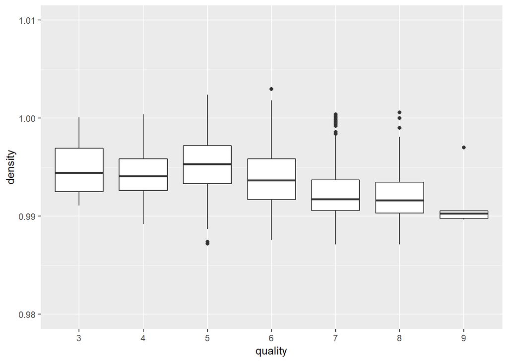

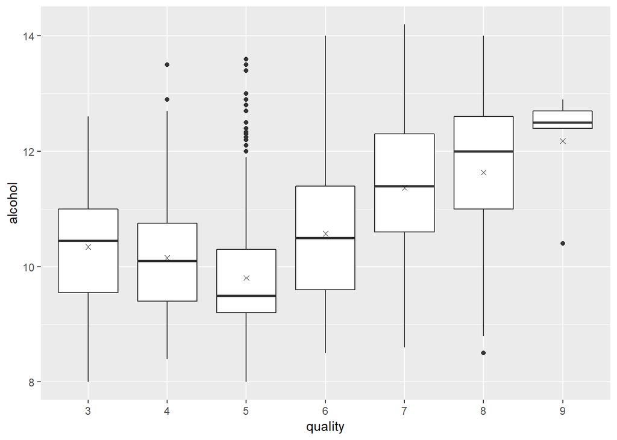

I tune the y axis a little and we can observe that wine have higher quality seems have lower density, and when it’s quality is higher, it has higher mean of alcohol.

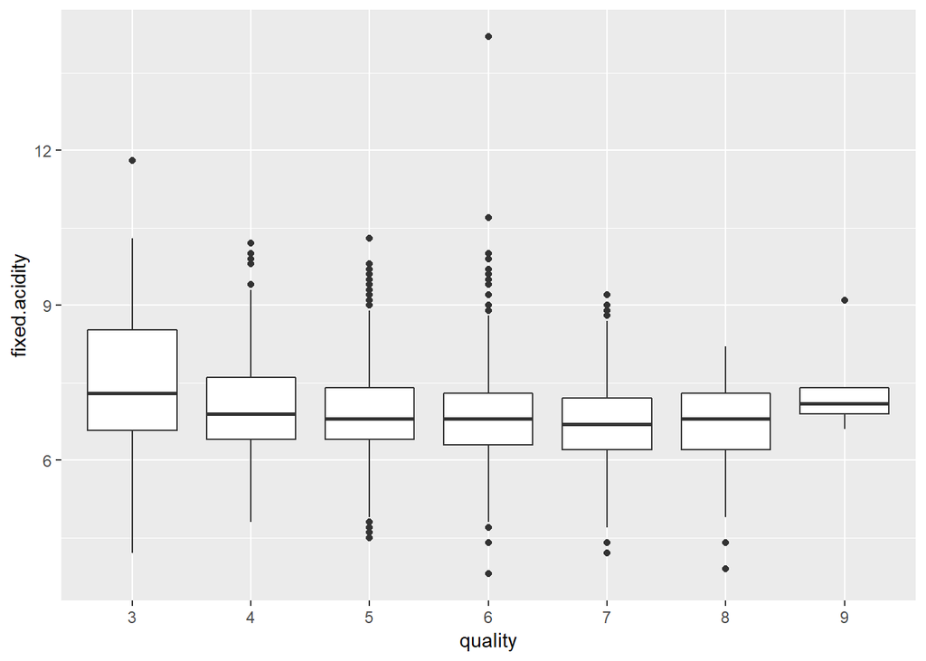

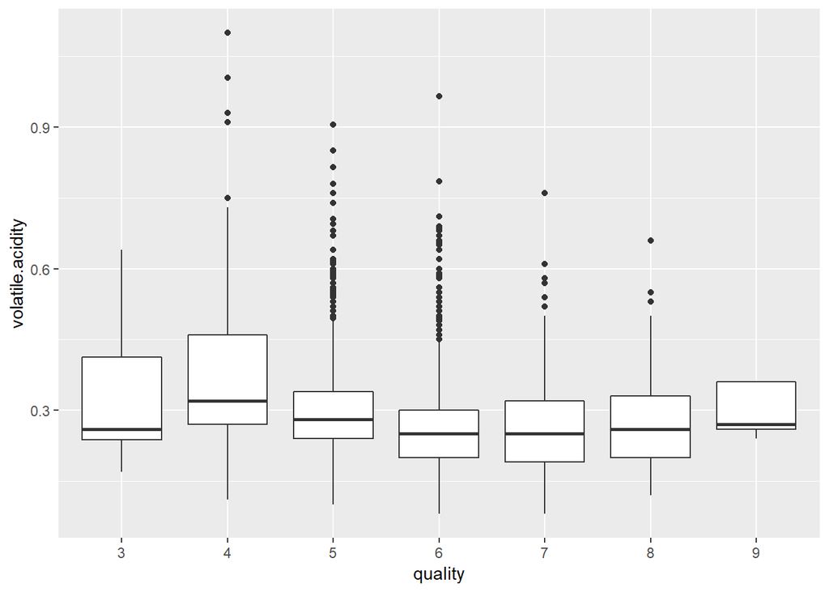

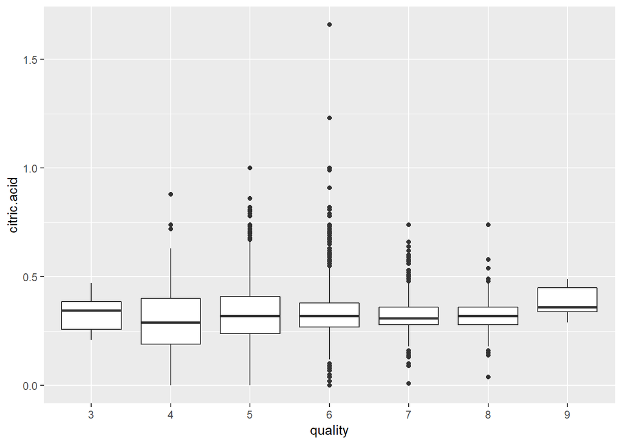

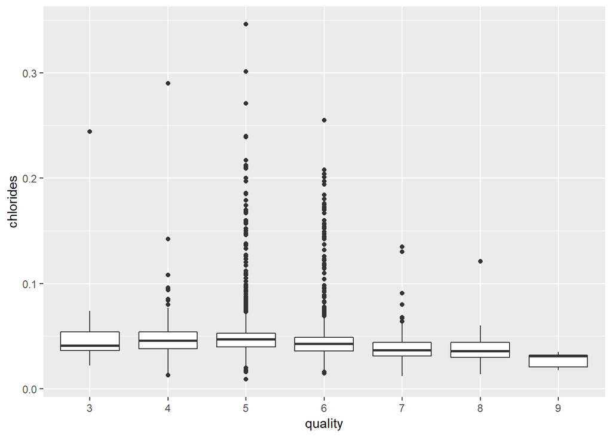

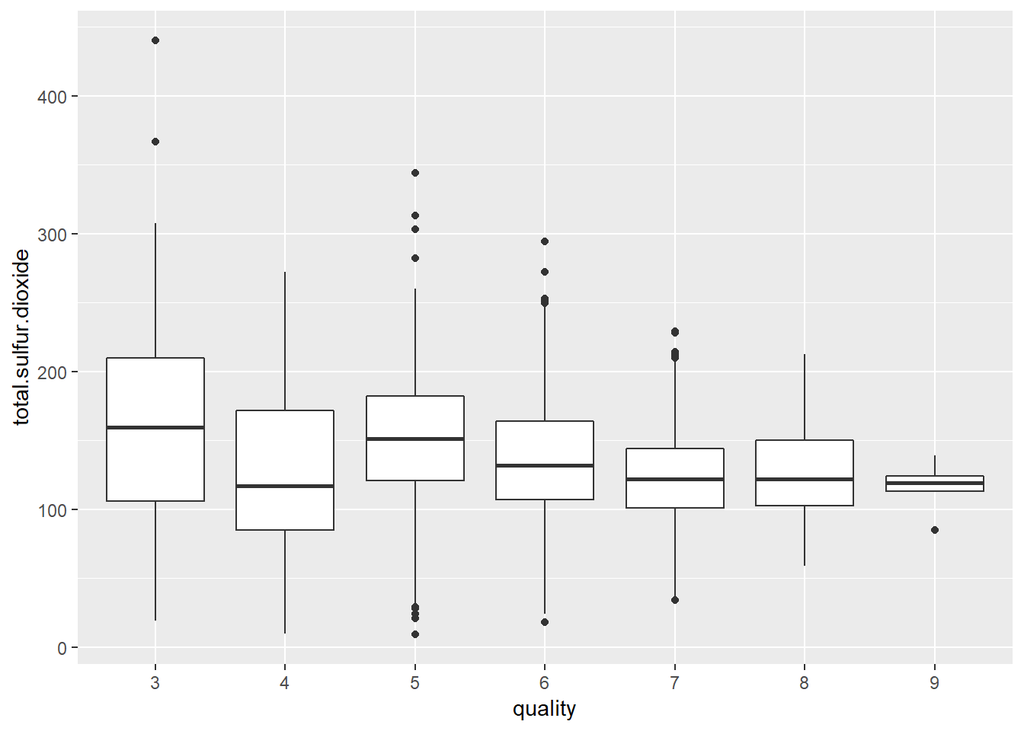

At last, from boxplot, `quality` has a weak relation with `fixed acidity`, `volatile acidity`, `chlorides` and `total sulfur dioxide`, but seems little more concentrate with `citric acid`.

So, through our exploration, I think we may use `residual sugar` , `alcohol`, `fixed acidity`, `volatile acidity`, `chlorides` and `total sulfur dioxide` to model the quality of the wine. On the other hand, `quality` variable is categorical data with multiple values, so we need svm function to predict it.

# Bivariate Analysis

### Talk about some of the relationships you observed in this part of the investigation. How did the feature(s) of interest vary with other features in the dataset?

- For quality, we plot some boxplot with other variables. The wine have higher quality seems have lower density, and when it’s quality is higher, it has higher mean of alcohol. citric acid is little more concentrate if the wine have high quality.As for other variables, there’s not obvious relation between them.

### What was the strongest relationship you found?

I think the most strongest relationship is between density, residual.sugar and alcohol. From the linear model I get, it has highest R^2 near 1 and lowest deviance near 0.

# Multivariate Plots Section

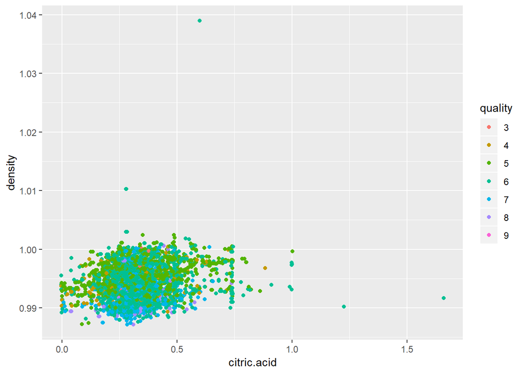

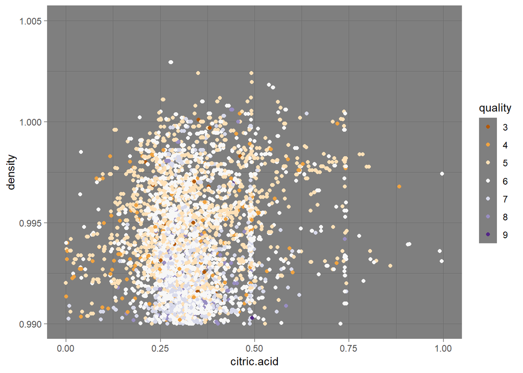

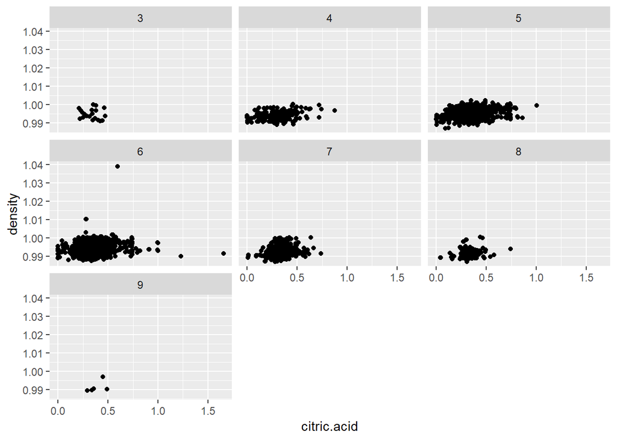

From this scatter plot, we can observe that wine with higher quality seems gather around at some point, which makes it suitable to use svm model it rather linear model.

```
##       y1
## result    3    4    5    6    7    8    9
##      3    0    0    3   17    0    0    0
##      4    0    0   14  149    0    0    0
##      5    0    0  209 1246    2    0    0
##      6    0    0  195 2000    3    0    0
##      7    0    0   59  814    7    0    0
##      8    0    0    9  165    1    0    0
##      9    0    0    0    5    0    0    0
```

```
##       y2
## result    3    4    5    6    7    8    9
##      3    0    0    6   13    1    0    0
##      4    0    0   58  101    4    0    0
##      5    0    0  673  779    5    0    0
##      6    0    0  474 1661   63    0    0
##      7    0    0   70  694  116    0    0
##      8    0    0   19  123   33    0    0
##      9    0    0    0    4    1    0    0
```

```
##       y3
## result    3    4    5    6    7    8    9
##      3    2    0    7   11    0    0    0
##      4    0   12   92   56    3    0    0
##      5    0    2  844  603    8    0    0
##      6    0    0  353 1756   89    0    0
##      7    0    0   19  662  199    0    0
##      8    0    0    2  126   47    0    0
##      9    0    0    0    3    2    0    0
```

```
##       y4
## result    3    4    5    6    7    8    9
##      3    1    0    7   12    0    0    0
##      4    0   20   96   45    2    0    0
##      5    0    1  930  522    4    0    0
##      6    0    0  333 1793   72    0    0
##      7    0    0   21  584  275    0    0
##      8    0    0    1  119   55    0    0
##      9    0    0    0    3    2    0    0
```

```
##       y1.after_tune
## result    3    4    5    6    7    8    9
##      3    0    0    4   16    0    0    0
##      4    0    0   16  147    0    0    0
##      5    0    0  244 1213    0    0    0
##      6    0    0  220 1978    0    0    0
##      7    0    0   66  814    0    0    0
##      8    0    0   17  158    0    0    0
##      9    0    0    0    5    0    0    0
```

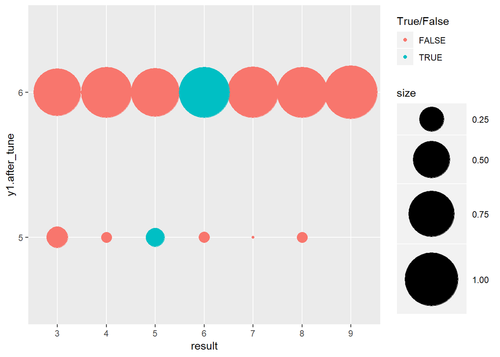

```
##       y4.after_tune
## result    3    4    5    6    7    8    9
##      3   20    0    0    0    0    0    0
##      4    0  163    0    0    0    0    0
##      5    0    0 1452    5    0    0    0
##      6    0    0    7 2189    1    1    0
##      7    0    0    0    3  877    0    0
##      8    0    0    0    0    0  175    0
##      9    0    0    0    0    0    0    5
```

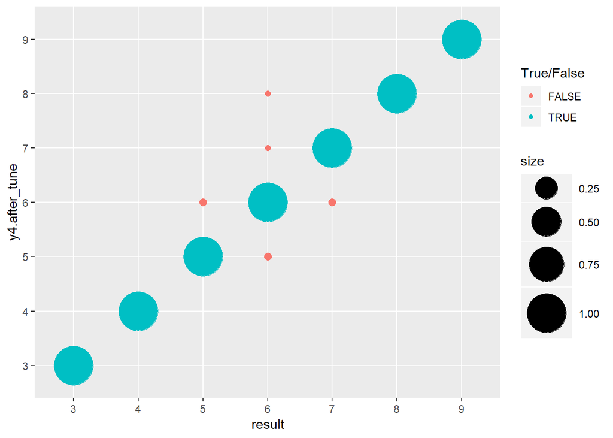

From table above, we can conclude that model use more parameters has a better performance. We also draw a bubble plot for model 1 which only use density and model 4, which use all variables.

# Multivariate Analysis

### Talk about some of the relationships you observed in this part of the investigation. Were there features that strengthened each other in terms of looking at your feature(s) of interest?

In citric.acid and density plot, wine with higher quality seems gather around at some point. In model we built, it seems more variables we use, more accurate model we’ll get.

### Were there any interesting or surprising interactions between features?

Build model with density, will cause a severe inaccurate prediction in the model.

### OPTIONAL: Did you create any models with your dataset? Discuss the strengths and limitations of your model.

Yes. I’ve built four svm models to predict the quality of wine, one only use density variable, which have a terrible result, one use sugar and alcohol to substitude density, is also not good. The third one is built with model I think relative with quality, it’s better, but also get much fault. Last model used all variables, which seems best among four models. I didn’t set a test set to evaluate the ability of model, but the other three are so bad on training set, it seems model 4 absolutely the best among them.

As for model 4, it uses all variables, but I still wonder if there any relation between variables I didn’t notice, which could reduce variables I use to create the model.

# Final Plots and Summary

### Plot One

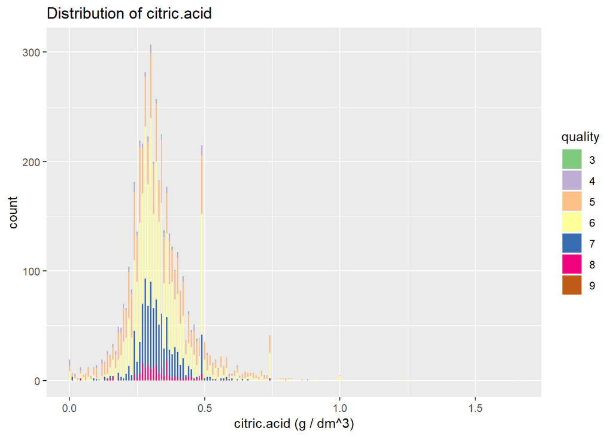

### Plot Two

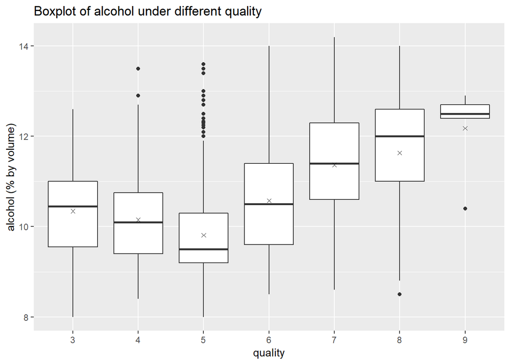

### Description Two

I built the boxplot with alcohol and plot mean value of each quality of wine, it seems high quality of wine have a higher mean and narrow range of data, which could be the effect of small sample, but it still indicate that there’s some relation between quality and alcohol.

### Plot Three

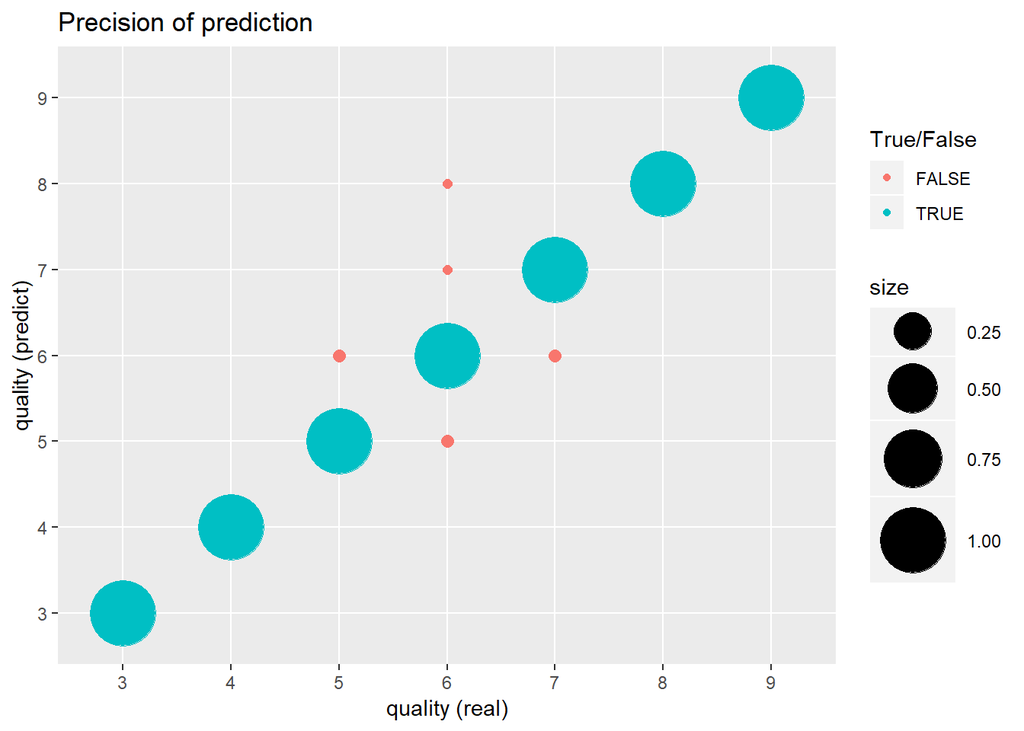

### Description Three

To make sense of model, I plot a bubble plot based on real result and result the model predice. In this plot, false prediction is plot in red. The size of point is decided by #prediction_value / #True_value, so we can see quality 3, 4, 8, 9 get a 100% prediction, and quality 5, 6, 7 have some false prediction, but almost perfect.

# Reflection

The white wine data set contains information of 4,898 bottles of wine. I started by understanding the individual variables from txt file provided, and then split the data into three relations, the amount of sulfur contained, density and quality. I hope there’s some variables could substiude information of sulfur contained and density, then I could use less variables to make model.

I notice that domain knowledge may help us make a better guess of relation between variables, it may make our model more simple and efficient.

Since it’s first time to analysis relation between continuous variables and categorical object, I know there’s lots of flaws. During analyse, I wonder if there’s any other plots could help us better understand relation between categorical variable and continuous variable other than boxplot.

# Reference

[SVM - Rdocumentation](https://www.rdocumentation.org/packages/e1071/versions/1.7-0/topics/svm)

[SVM - tune](https://rischanlab.github.io/SVM.html)

[Bubble plot](https://www.r-graph-gallery.com/320-the-basis-of-bubble-plot/)

[change legend](https://stackoverflow.com/questions/14622421/how-to-change-legend-title-in-ggplot)

P. Cortez, A. Cerdeira, F. Almeida, T. Matos and J. Reis. Modeling wine preferences by data mining from physicochemical properties. In Decision Support Systems, Elsevier, 47(4):547-553. ISSN: 0167-9236.

Available at: [@Elsevier] http://dx.doi.org/10.1016/j.dss.2009.05.016 [Pre-press (pdf)] http://www3.dsi.uminho.pt/pcortez/winequality09.pdf [bib] http://www3.dsi.uminho.pt/pcortez/dss09.bib